# Reconstructing the xraylines dataset

Taha Ahmed

2023-03-20

Having a list of all X-ray transitions of the elements is quite useful, in particular when analysing X-ray fluorescence spectra.

This dataset was based on a dataset of line energies included with the PANalytical Epsilon 5 instrument’s software version 2.0J/ICSW 2.8 of Dec 7, 2010 with kernel PW5050. In the Epsilon program, data on every transition’s energy and relative intensity (as well as edge energies for each element) were stored in a user-accessible format (but had to be manually transcribed, which yours truly did).

I combined the Epsilon 5 dataset with the freely available dataset of Kaye & Laby, and where the they diverged (usually at the third decimal) I gave priority to the former on account of it being much more recent and provided by a reputed instrument maker.

Finally, I extended this combined dataset by adding natural line widths and fluorescence yields for each transition from the works of Krause & Oliver (1979) and Krause (1979).

My original, detailed notes on this work is [available on my blog](https://solarchemist.se/2014/09/13/xray-line-energies).

In the following we will just briefly demonstrate the process of constructing the dataset published in this package.

Fetch the original, manually curated dataset (LibreOffice spreadsheet hosted on Figshare):

```r
utils::download.file(
   url = "https://ndownloader.figshare.com/files/3222110",
   destfile = here::here("inst/extdata/xray-lines.ods"))
```

Note that this spreadsheet uses the IUPAC notation throughout, but some might prefer the (no longer recommended) Siegbahn notation. For that purpose, I created a “best effort” [correspondence table](https://solarchemist.se/2014/09/13/xray-line-energies/#notation-iupac-more-stringent-than-siegbahn).

The dataset in this package was constructed from the ODS spreadsheet with the following script:

```r
xraydata <- readODS::read_ods(here::here("inst/extdata/xray-lines.ods"), sheet = 1)
# fix header
names(xraydata) <- xraydata[1,]
xraydata <- xraydata[-1, ]
row.names(xraydata) <- seq(1, dim(xraydata)[1])
# add label columns to xraydata
xraydata[, column.labels] <- ""
# warning: this loop is quite slow
for (j in 1:dim(xraydata)[1]) {
   # loop over each row in xraydata
   for (k in 1:length(column.labels)) {
      # loop over each element in the added column labels
      if (xraydata$transition[j] != "") {
         # only for transitions, do...
         xraydata[j, column.labels[k]] <-
            xray.labels[
               which(xray.labels$IUPAC == xraydata$transition[j]),
               which(names(xray.labels) == column.labels[k])]
      }
      if (xraydata$edge[j] != "") {
         # only for edges, do...
         xraydata$IUPAC.formatted[j] <-
            xray.labels$IUPAC.formatted[which(xray.labels$IUPAC == xraydata$edge[j])]
      }
   }
}
# Create uniqueid for each xraydata row
xraydata$uid <- paste(
   xraydata$Z,
   xraydata$element,
   ifelse(
      xraydata$transition != "",
      xraydata$transition,
      xraydata$edge),
   sep = "-")
# reset some columns to numeric (currently they are all character)
xraydata$Z                  <- as.numeric(xraydata$Z)
xraydata$transition.keV     <- as.numeric(xraydata$transition.keV)
xraydata$intensity          <- as.numeric(xraydata$intensity)
xraydata$width.eV           <- as.numeric(xraydata$width.eV)
xraydata$edge.keV           <- as.numeric(xraydata$edge.keV)
xraydata$fluorescence.yield <- as.numeric(xraydata$fluorescence.yield)
save(xraydata, file = here::here("data/xray-line-energies.rda"))
```

This package also includes a line-matching algorithm I created to help pick out matching elemental X-ray lines given a list of observed energies. Please note that this was some of the first code I wrote as a doctoral student (in chemistry, to be clear) and it is incuded here as-was. I did, however, use this function successfully in many reports for in-house consumption. Here is how it could look (in a nicely formatted LaTeX table):

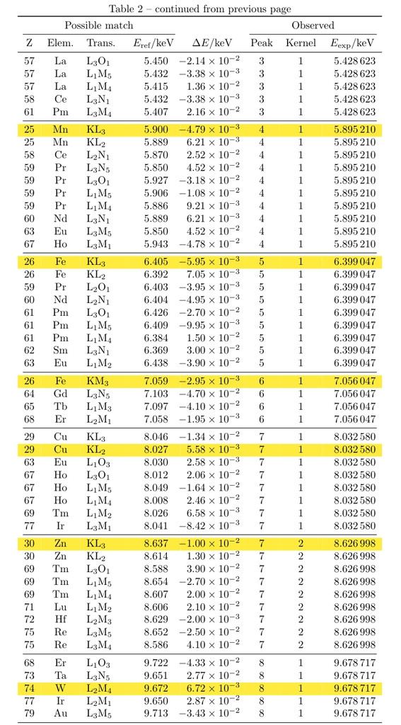

This package is shared in the hopes you may find this dataset and algorithm useful!

## References

- https://solarchemist.se/2014/09/13/xray-line-energies
- [Kaye & Laby, Tables of Physical & Chemical Constants, US National Physical Laboratory](https://web.archive.org/web/20190511222636/http://www.kayelaby.npl.co.uk/atomic_and_nuclear_physics/4_2/4_2_1.html)
- Krause & Oliver, 1979. Natural widths of atomic K and L levels, Kα X-ray lines and several KLL Auger lines. Journal of Physical and Chemical Reference Data 8, 329. https://doi.org/10.1063/1.555595
- Krause, 1979. Atomic radiative and radiationless yields for K and L shells. Journal of Physical and Chemical Reference Data 8, 307-327. https://doi.org/10.1063/1.555594
- https://en.wikipedia.org/wiki/X-ray_notation